# Risk Factor Analysis

## Outcome Variable

**Outcome Variable:** haz

## Predictor Variables

**Intervention Variable:** mbmi

**Adjustment Set:**

- arm
- W_mage
- meducyrs
- feducyrs
- hhwealth_quart
- brthmon
- W_parity
- impfloor
- impsan
- safeh20
- delta_W_mage
- delta_meducyrs
- delta_feducyrs
- delta_hhwealth_quart
- delta_brthmon
- delta_W_parity
- delta_impfloor
- delta_impsan
- delta_safeh20

## Stratifying Variables

The analysis was stratified on these variable(s):

- agecat
- studyid
- country

## Data Summary

| agecat | studyid | country | mbmi | n_cell | n | outcome_variable |
| --- | --- | --- | --- | --- | --- | --- |
| Birth | JiVitA-3 | BANGLADESH | Normal weight | 13720 | 22355 | haz |
| Birth | JiVitA-3 | BANGLADESH | Underweight | 8635 | 22355 | haz |
| Birth | MAL-ED | BANGLADESH | Normal weight | 194 | 222 | haz |
| Birth | MAL-ED | BANGLADESH | Underweight | 28 | 222 | haz |
| Birth | MAL-ED | BRAZIL | Normal weight | 59 | 64 | haz |
| Birth | MAL-ED | BRAZIL | Underweight | 5 | 64 | haz |
| Birth | MAL-ED | INDIA | Normal weight | 35 | 43 | haz |
| Birth | MAL-ED | INDIA | Underweight | 8 | 43 | haz |
| Birth | MAL-ED | NEPAL | Normal weight | 27 | 27 | haz |
| Birth | MAL-ED | NEPAL | Underweight | 0 | 27 | haz |
| Birth | MAL-ED | PERU | Normal weight | 221 | 226 | haz |
| Birth | MAL-ED | PERU | Underweight | 5 | 226 | haz |
| Birth | MAL-ED | SOUTH AFRICA | Normal weight | 98 | 101 | haz |
| Birth | MAL-ED | SOUTH AFRICA | Underweight | 3 | 101 | haz |
| Birth | MAL-ED | TANZANIA, UNITED REPUBLIC OF | Normal weight | 115 | 122 | haz |
| Birth | MAL-ED | TANZANIA, UNITED REPUBLIC OF | Underweight | 7 | 122 | haz |
| Birth | NIH-Birth | BANGLADESH | Normal weight | 506 | 608 | haz |
| Birth | NIH-Birth | BANGLADESH | Underweight | 102 | 608 | haz |
| Birth | NIH-Crypto | BANGLADESH | Normal weight | 663 | 729 | haz |
| Birth | NIH-Crypto | BANGLADESH | Underweight | 66 | 729 | haz |
| Birth | PROBIT | BELARUS | Normal weight | 13203 | 13726 | haz |
| Birth | PROBIT | BELARUS | Underweight | 523 | 13726 | haz |
| Birth | PROVIDE | BANGLADESH | Normal weight | 418 | 517 | haz |
| Birth | PROVIDE | BANGLADESH | Underweight | 99 | 517 | haz |
| Birth | SAS-CompFeed | INDIA | Normal weight | 830 | 1135 | haz |
| Birth | SAS-CompFeed | INDIA | Underweight | 305 | 1135 | haz |
| Birth | ZVITAMBO | ZIMBABWE | Normal weight | 9162 | 9672 | haz |
| Birth | ZVITAMBO | ZIMBABWE | Underweight | 510 | 9672 | haz |
| 6 months | JiVitA-3 | BANGLADESH | Normal weight | 10311 | 16760 | haz |
| 6 months | JiVitA-3 | BANGLADESH | Underweight | 6449 | 16760 | haz |

[output cut: 60 more lines]

The following strata were considered:

- agecat: 24 months, studyid: JiVitA-3, country: BANGLADESH
- agecat: 24 months, studyid: LCNI-5, country: MALAWI
- agecat: 24 months, studyid: MAL-ED, country: BANGLADESH
- agecat: 24 months, studyid: MAL-ED, country: BRAZIL
- agecat: 24 months, studyid: MAL-ED, country: INDIA
- agecat: 24 months, studyid: MAL-ED, country: NEPAL
- agecat: 24 months, studyid: MAL-ED, country: PERU
- agecat: 24 months, studyid: MAL-ED, country: SOUTH AFRICA
- agecat: 24 months, studyid: MAL-ED, country: TANZANIA, UNITED REPUBLIC OF
- agecat: 24 months, studyid: NIH-Birth, country: BANGLADESH
- agecat: 24 months, studyid: NIH-Crypto, country: BANGLADESH
- agecat: 24 months, studyid: PROBIT, country: BELARUS
- agecat: 24 months, studyid: PROVIDE, country: BANGLADESH
- agecat: 24 months, studyid: TanzaniaChild2, country: TANZANIA, UNITED REPUBLIC OF
- agecat: 24 months, studyid: ZVITAMBO, country: ZIMBABWE
- agecat: 6 months, studyid: JiVitA-3, country: BANGLADESH
- agecat: 6 months, studyid: LCNI-5, country: MALAWI
- agecat: 6 months, studyid: MAL-ED, country: BANGLADESH
- agecat: 6 months, studyid: MAL-ED, country: BRAZIL
- agecat: 6 months, studyid: MAL-ED, country: INDIA
- agecat: 6 months, studyid: MAL-ED, country: NEPAL
- agecat: 6 months, studyid: MAL-ED, country: PERU
- agecat: 6 months, studyid: MAL-ED, country: SOUTH AFRICA
- agecat: 6 months, studyid: MAL-ED, country: TANZANIA, UNITED REPUBLIC OF
- agecat: 6 months, studyid: NIH-Birth, country: BANGLADESH
- agecat: 6 months, studyid: NIH-Crypto, country: BANGLADESH
- agecat: 6 months, studyid: PROBIT, country: BELARUS
- agecat: 6 months, studyid: PROVIDE, country: BANGLADESH
- agecat: 6 months, studyid: SAS-CompFeed, country: INDIA
- agecat: 6 months, studyid: TanzaniaChild2, country: TANZANIA, UNITED REPUBLIC OF
- agecat: 6 months, studyid: ZVITAMBO, country: ZIMBABWE
- agecat: Birth, studyid: JiVitA-3, country: BANGLADESH
- agecat: Birth, studyid: MAL-ED, country: BANGLADESH
- agecat: Birth, studyid: MAL-ED, country: BRAZIL
- agecat: Birth, studyid: MAL-ED, country: INDIA
- agecat: Birth, studyid: MAL-ED, country: NEPAL
- agecat: Birth, studyid: MAL-ED, country: PERU
- agecat: Birth, studyid: MAL-ED, country: SOUTH AFRICA
- agecat: Birth, studyid: MAL-ED, country: TANZANIA, UNITED REPUBLIC OF
- agecat: Birth, studyid: NIH-Birth, country: BANGLADESH
- agecat: Birth, studyid: NIH-Crypto, country: BANGLADESH
- agecat: Birth, studyid: PROBIT, country: BELARUS
- agecat: Birth, studyid: PROVIDE, country: BANGLADESH
- agecat: Birth, studyid: SAS-CompFeed, country: INDIA
- agecat: Birth, studyid: ZVITAMBO, country: ZIMBABWE

### Dropped Strata

Some strata were dropped due to rare outcomes:

- agecat: Birth, studyid: MAL-ED, country: NEPAL
- agecat: Birth, studyid: MAL-ED, country: SOUTH AFRICA
- agecat: 6 months, studyid: MAL-ED, country: NEPAL
- agecat: 24 months, studyid: MAL-ED, country: NEPAL
- agecat: 24 months, studyid: MAL-ED, country: PERU
- agecat: 24 months, studyid: TanzaniaChild2, country: TANZANIA, UNITED REPUBLIC OF

## Methods Detail

We’re interested in the causal parameters $E[Y_a]$ for all values of $a \in \mathcal{A}$. These parameters represent the mean outcome if, possibly contrary to fact, we intervened to set all units to have $A=a$. Under the randomization and positivity assumptions, these are identified by the statistical parameters $\psi_a=E_W[E_{Y|A,W}(Y|A=a,W)]$. In addition, we’re interested in the mean of $Y$, $E[Y]$ under no intervention (the observed mean). We will estimate these parameters by using SuperLearner to fit the relevant likelihood factors – $E_{Y|A,W}(Y|A=a,W)$ and $p(A=a|W)$, and then updating our likelihood fit using a joint TMLE.

For unadjusted analyses ($W=\{\}$), initial likelihoods were estimated using Lrnr_glm to estimate the simple $E(Y|A)$ and Lrnr_mean to estimate $p(A)$. For adjusted analyses, a small library containing Lrnr_glmnet, Lrnr_xgboost, and Lrnr_mean was used.

Having estimated these parameters, we will then use the delta method to estimate relative risks and attributable risks relative to a prespecified baseline level of $A$.

# Results Detail

## Results Plots

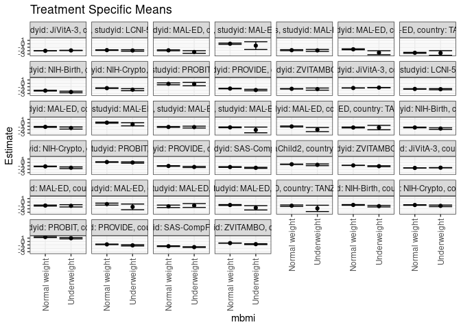

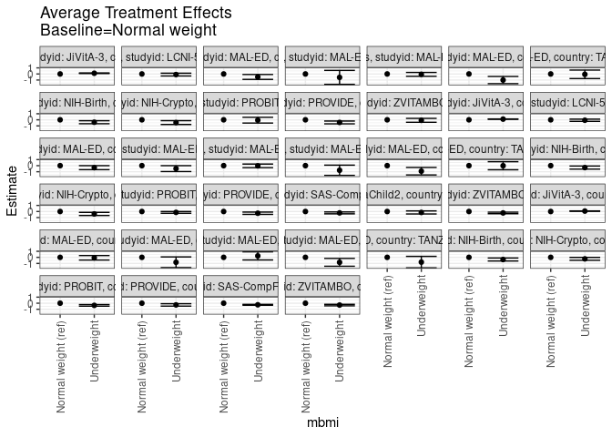

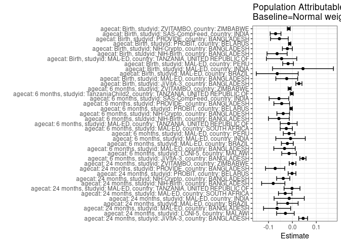

## Results Table

### Parameter: TSM

| agecat | studyid | country | intervention_level | baseline_level | estimate | ci_lower | ci_upper |
| --- | --- | --- | --- | --- | --- | --- | --- |
| Birth | JiVitA-3 | BANGLADESH | Normal weight | NA | -1.6165577 | -1.6397412 | -1.5933743 |
| Birth | JiVitA-3 | BANGLADESH | Underweight | NA | -1.5462821 | -1.5744324 | -1.5181317 |
| Birth | MAL-ED | BANGLADESH | Normal weight | NA | -1.0540900 | -1.2009445 | -0.9072355 |
| Birth | MAL-ED | BANGLADESH | Underweight | NA | -1.1297619 | -1.4674788 | -0.7920450 |
| Birth | MAL-ED | BRAZIL | Normal weight | NA | -0.6249153 | -0.9137560 | -0.3360745 |
| Birth | MAL-ED | BRAZIL | Underweight | NA | -1.4380000 | -2.2732876 | -0.6027124 |
| Birth | MAL-ED | INDIA | Normal weight | NA | -1.2745714 | -1.6299983 | -0.9191446 |
| Birth | MAL-ED | INDIA | Underweight | NA | -1.0362500 | -1.6020040 | -0.4704960 |
| Birth | MAL-ED | PERU | Normal weight | NA | -0.8869683 | -1.0065725 | -0.7673641 |
| Birth | MAL-ED | PERU | Underweight | NA | -1.7080000 | -2.3409322 | -1.0750678 |
| Birth | MAL-ED | TANZANIA, UNITED REPUBLIC OF | Normal weight | NA | -1.0913043 | -1.3056634 | -0.8769453 |
| Birth | MAL-ED | TANZANIA, UNITED REPUBLIC OF | Underweight | NA | -1.8785714 | -2.8008825 | -0.9562603 |
| Birth | NIH-Birth | BANGLADESH | Normal weight | NA | -0.8668952 | -0.9624106 | -0.7713799 |
| Birth | NIH-Birth | BANGLADESH | Underweight | NA | -1.2239141 | -1.4535291 | -0.9942991 |
| Birth | NIH-Crypto | BANGLADESH | Normal weight | NA | -0.8878172 | -0.9640065 | -0.8116279 |
| Birth | NIH-Crypto | BANGLADESH | Underweight | NA | -1.1375005 | -1.3644115 | -0.9105894 |
| Birth | PROBIT | BELARUS | Normal weight | NA | 1.3234336 | 1.1631651 | 1.4837020 |
| Birth | PROBIT | BELARUS | Underweight | NA | 0.9642530 | 0.7796850 | 1.1488210 |
| Birth | PROVIDE | BANGLADESH | Normal weight | NA | -0.8380201 | -0.9228375 | -0.7532028 |
| Birth | PROVIDE | BANGLADESH | Underweight | NA | -1.1216399 | -1.2996459 | -0.9436339 |
| Birth | SAS-CompFeed | INDIA | Normal weight | NA | -1.3733276 | -1.4687330 | -1.2779222 |
| Birth | SAS-CompFeed | INDIA | Underweight | NA | -1.6367608 | -1.7433420 | -1.5301795 |
| Birth | ZVITAMBO | ZIMBABWE | Normal weight | NA | -0.4611058 | -0.4861630 | -0.4360486 |
| Birth | ZVITAMBO | ZIMBABWE | Underweight | NA | -0.7690033 | -0.8891744 | -0.6488321 |
| 6 months | JiVitA-3 | BANGLADESH | Normal weight | NA | -1.3581076 | -1.3849181 | -1.3312971 |
| 6 months | JiVitA-3 | BANGLADESH | Underweight | NA | -1.2446252 | -1.2750569 | -1.2141935 |
| 6 months | LCNI-5 | MALAWI | Normal weight | NA | -1.6436094 | -1.7218132 | -1.5654057 |
| 6 months | LCNI-5 | MALAWI | Underweight | NA | -1.7163335 | -1.8799536 | -1.5527133 |
| 6 months | MAL-ED | BANGLADESH | Normal weight | NA | -1.1719501 | -1.2972021 | -1.0466981 |
| 6 months | MAL-ED | BANGLADESH | Underweight | NA | -1.5048156 | -1.8090389 | -1.2005924 |
| 6 months | MAL-ED | BRAZIL | Normal weight | NA | 0.0708375 | -0.0781476 | 0.2198227 |
| 6 months | MAL-ED | BRAZIL | Underweight | NA | -0.4164815 | -0.8769172 | 0.0439543 |
| 6 months | MAL-ED | INDIA | Normal weight | NA | -1.1981162 | -1.3313812 | -1.0648513 |
| 6 months | MAL-ED | INDIA | Underweight | NA | -1.2346416 | -1.5020608 | -0.9672224 |
| 6 months | MAL-ED | PERU | Normal weight | NA | -1.3101467 | -1.4185443 | -1.2017491 |
| 6 months | MAL-ED | PERU | Underweight | NA | -2.0693333 | -2.9031517 | -1.2355150 |
| 6 months | MAL-ED | SOUTH AFRICA | Normal weight | NA | -1.0471625 | -1.1780920 | -0.9162331 |
| 6 months | MAL-ED | SOUTH AFRICA | Underweight | NA | -1.9571429 | -2.5636947 | -1.3505910 |
| 6 months | MAL-ED | TANZANIA, UNITED REPUBLIC OF | Normal weight | NA | -1.3531579 | -1.4771546 | -1.2291613 |
| 6 months | MAL-ED | TANZANIA, UNITED REPUBLIC OF | Underweight | NA | -1.3667431 | -2.0188833 | -0.7146029 |
| 6 months | NIH-Birth | BANGLADESH | Normal weight | NA | -1.3508188 | -1.4458468 | -1.2557909 |
| 6 months | NIH-Birth | BANGLADESH | Underweight | NA | -1.6698829 | -1.9052513 | -1.4345145 |
| 6 months | NIH-Crypto | BANGLADESH | Normal weight | NA | -1.1601375 | -1.2341475 | -1.0861274 |
| 6 months | NIH-Crypto | BANGLADESH | Underweight | NA | -1.5600562 | -1.8047912 | -1.3153211 |
| 6 months | PROBIT | BELARUS | Normal weight | NA | 0.1131695 | 0.0233627 | 0.2029763 |
| 6 months | PROBIT | BELARUS | Underweight | NA | -0.0299780 | -0.2172531 | 0.1572970 |
| 6 months | PROVIDE | BANGLADESH | Normal weight | NA | -1.0446814 | -1.1284024 | -0.9609604 |
| 6 months | PROVIDE | BANGLADESH | Underweight | NA | -1.3283823 | -1.4982320 | -1.1585325 |
| 6 months | SAS-CompFeed | INDIA | Normal weight | NA | -1.3505682 | -1.4534104 | -1.2477259 |
| 6 months | SAS-CompFeed | INDIA | Underweight | NA | -1.5790690 | -1.7226816 | -1.4354564 |
| 6 months | TanzaniaChild2 | TANZANIA, UNITED REPUBLIC OF | Normal weight | NA | -0.5378475 | -0.5881229 | -0.4875721 |
| 6 months | TanzaniaChild2 | TANZANIA, UNITED REPUBLIC OF | Underweight | NA | -0.6943795 | -0.9431587 | -0.4456003 |
| 6 months | ZVITAMBO | ZIMBABWE | Normal weight | NA | -0.8683495 | -0.8965329 | -0.8401662 |
| 6 months | ZVITAMBO | ZIMBABWE | Underweight | NA | -1.1048089 | -1.2302174 | -0.9794003 |
| 24 months | JiVitA-3 | BANGLADESH | Normal weight | NA | -2.0587683 | -2.0925517 | -2.0249849 |
| 24 months | JiVitA-3 | BANGLADESH | Underweight | NA | -1.9426860 | -1.9824625 | -1.9029096 |
| 24 months | LCNI-5 | MALAWI | Normal weight | NA | -1.8559157 | -1.9448791 | -1.7669523 |
| 24 months | LCNI-5 | MALAWI | Underweight | NA | -1.9577452 | -2.1663947 | -1.7490956 |
| 24 months | MAL-ED | BANGLADESH | Normal weight | NA | -1.9143154 | -2.0449468 | -1.7836841 |
| 24 months | MAL-ED | BANGLADESH | Underweight | NA | -2.4071992 | -2.7890328 | -2.0253656 |
| 24 months | MAL-ED | BRAZIL | Normal weight | NA | 0.0261008 | -0.1439691 | 0.1961708 |
| 24 months | MAL-ED | BRAZIL | Underweight | NA | -0.5391667 | -1.6773310 | 0.5989977 |
| 24 months | MAL-ED | INDIA | Normal weight | NA | -1.8709576 | -2.0114052 | -1.7305100 |
| 24 months | MAL-ED | INDIA | Underweight | NA | -1.9372204 | -2.2195346 | -1.6549062 |
| 24 months | MAL-ED | SOUTH AFRICA | Normal weight | NA | -1.6131241 | -1.7506877 | -1.4755605 |
| 24 months | MAL-ED | SOUTH AFRICA | Underweight | NA | -2.6192857 | -3.1998173 | -2.0387542 |
| 24 months | MAL-ED | TANZANIA, UNITED REPUBLIC OF | Normal weight | NA | -2.6439336 | -2.7826574 | -2.5052098 |
| 24 months | MAL-ED | TANZANIA, UNITED REPUBLIC OF | Underweight | NA | -2.7035981 | -3.3922910 | -2.0149053 |
| 24 months | NIH-Birth | BANGLADESH | Normal weight | NA | -2.1387662 | -2.2520904 | -2.0254420 |
| 24 months | NIH-Birth | BANGLADESH | Underweight | NA | -2.5382239 | -2.7604392 | -2.3160087 |
| 24 months | NIH-Crypto | BANGLADESH | Normal weight | NA | -1.4028731 | -1.4894930 | -1.3162533 |
| 24 months | NIH-Crypto | BANGLADESH | Underweight | NA | -1.8582326 | -2.1600807 | -1.5563845 |
| 24 months | PROBIT | BELARUS | Normal weight | NA | -0.1427916 | -0.4282054 | 0.1426221 |
| 24 months | PROBIT | BELARUS | Underweight | NA | -0.2051698 | -0.6880845 | 0.2777448 |
| 24 months | PROVIDE | BANGLADESH | Normal weight | NA | -1.5281002 | -1.6175309 | -1.4386695 |
| 24 months | PROVIDE | BANGLADESH | Underweight | NA | -1.9600101 | -2.1744486 | -1.7455715 |
| 24 months | ZVITAMBO | ZIMBABWE | Normal weight | NA | -1.5989426 | -1.6625397 | -1.5353456 |
| 24 months | ZVITAMBO | ZIMBABWE | Underweight | NA | -1.6861555 | -2.0018086 | -1.3705023 |

### Parameter: E(Y)

| agecat | studyid | country | intervention_level | baseline_level | estimate | ci_lower | ci_upper |
| --- | --- | --- | --- | --- | --- | --- | --- |
| Birth | JiVitA-3 | BANGLADESH | NA | NA | -1.5893196 | -1.6086080 | -1.5700313 |
| Birth | MAL-ED | BANGLADESH | NA | NA | -1.0778829 | -1.2122580 | -0.9435077 |
| Birth | MAL-ED | BRAZIL | NA | NA | -0.6884375 | -0.9678371 | -0.4090379 |
| Birth | MAL-ED | INDIA | NA | NA | -1.2302326 | -1.5393614 | -0.9211037 |
| Birth | MAL-ED | PERU | NA | NA | -0.9051327 | -1.0238686 | -0.7863969 |
| Birth | MAL-ED | TANZANIA, UNITED REPUBLIC OF | NA | NA | -1.1364754 | -1.3478823 | -0.9250686 |
| Birth | NIH-Birth | BANGLADESH | NA | NA | -0.9310197 | -1.0197391 | -0.8423003 |
| Birth | NIH-Crypto | BANGLADESH | NA | NA | -0.9089163 | -0.9806324 | -0.8372002 |
| Birth | PROBIT | BELARUS | NA | NA | 1.3118585 | 1.1523374 | 1.4713797 |
| Birth | PROVIDE | BANGLADESH | NA | NA | -0.8925145 | -0.9687201 | -0.8163089 |
| Birth | SAS-CompFeed | INDIA | NA | NA | -1.4438150 | -1.5337502 | -1.3538797 |
| Birth | ZVITAMBO | ZIMBABWE | NA | NA | -0.4764413 | -0.5009156 | -0.4519670 |
| 6 months | JiVitA-3 | BANGLADESH | NA | NA | -1.3140048 | -1.3371141 | -1.2908955 |
| 6 months | LCNI-5 | MALAWI | NA | NA | -1.6577751 | -1.7275296 | -1.5880207 |
| 6 months | MAL-ED | BANGLADESH | NA | NA | -1.2049931 | -1.3222136 | -1.0877726 |
| 6 months | MAL-ED | BRAZIL | NA | NA | 0.0497516 | -0.0948051 | 0.1943083 |
| 6 months | MAL-ED | INDIA | NA | NA | -1.2059574 | -1.3243030 | -1.0876119 |
| 6 months | MAL-ED | PERU | NA | NA | -1.3241023 | -1.4325083 | -1.2156964 |
| 6 months | MAL-ED | SOUTH AFRICA | NA | NA | -1.0727443 | -1.2024880 | -0.9430006 |
| 6 months | MAL-ED | TANZANIA, UNITED REPUBLIC OF | NA | NA | -1.3687449 | -1.4907629 | -1.2467270 |
| 6 months | NIH-Birth | BANGLADESH | NA | NA | -1.4073821 | -1.4960598 | -1.3187043 |
| 6 months | NIH-Crypto | BANGLADESH | NA | NA | -1.1986783 | -1.2700937 | -1.1272630 |
| 6 months | PROBIT | BELARUS | NA | NA | 0.1076224 | 0.0168411 | 0.1984037 |
| 6 months | PROVIDE | BANGLADESH | NA | NA | -1.0895301 | -1.1639589 | -1.0151013 |
| 6 months | SAS-CompFeed | INDIA | NA | NA | -1.4068893 | -1.4981242 | -1.3156543 |
| 6 months | TanzaniaChild2 | TANZANIA, UNITED REPUBLIC OF | NA | NA | -0.5405711 | -0.5899965 | -0.4911457 |
| 6 months | ZVITAMBO | ZIMBABWE | NA | NA | -0.8800508 | -0.9074511 | -0.8526506 |
| 24 months | JiVitA-3 | BANGLADESH | NA | NA | -2.0137632 | -2.0415122 | -1.9860142 |
| 24 months | LCNI-5 | MALAWI | NA | NA | -1.8851820 | -1.9664818 | -1.8038822 |
| 24 months | MAL-ED | BANGLADESH | NA | NA | -1.9783962 | -2.1050210 | -1.8517715 |
| 24 months | MAL-ED | BRAZIL | NA | NA | 0.0059127 | -0.1637934 | 0.1756188 |
| 24 months | MAL-ED | INDIA | NA | NA | -1.8844690 | -2.0097879 | -1.7591502 |
| 24 months | MAL-ED | SOUTH AFRICA | NA | NA | -1.6432229 | -1.7795844 | -1.5068615 |
| 24 months | MAL-ED | TANZANIA, UNITED REPUBLIC OF | NA | NA | -2.6455607 | -2.7807256 | -2.5103959 |
| 24 months | NIH-Birth | BANGLADESH | NA | NA | -2.2190579 | -2.3217459 | -2.1163699 |
| 24 months | NIH-Crypto | BANGLADESH | NA | NA | -1.4412646 | -1.5249156 | -1.3576135 |
| 24 months | PROBIT | BELARUS | NA | NA | -0.1444149 | -0.4258602 | 0.1370304 |
| 24 months | PROVIDE | BANGLADESH | NA | NA | -1.6002600 | -1.6836163 | -1.5169036 |
| 24 months | ZVITAMBO | ZIMBABWE | NA | NA | -1.5983212 | -1.6605141 | -1.5361283 |

### Parameter: ATE

| agecat | studyid | country | intervention_level | baseline_level | estimate | ci_lower | ci_upper |
| --- | --- | --- | --- | --- | --- | --- | --- |
| Birth | JiVitA-3 | BANGLADESH | Normal weight | Normal weight | 0.0000000 | 0.0000000 | 0.0000000 |
| Birth | JiVitA-3 | BANGLADESH | Underweight | Normal weight | 0.0702757 | 0.0371080 | 0.1034433 |
| Birth | MAL-ED | BANGLADESH | Normal weight | Normal weight | 0.0000000 | 0.0000000 | 0.0000000 |
| Birth | MAL-ED | BANGLADESH | Underweight | Normal weight | -0.0756718 | -0.4449957 | 0.2936521 |
| Birth | MAL-ED | BRAZIL | Normal weight | Normal weight | 0.0000000 | 0.0000000 | 0.0000000 |
| Birth | MAL-ED | BRAZIL | Underweight | Normal weight | -0.8130847 | -1.6969028 | 0.0707333 |
| Birth | MAL-ED | INDIA | Normal weight | Normal weight | 0.0000000 | 0.0000000 | 0.0000000 |
| Birth | MAL-ED | INDIA | Underweight | Normal weight | 0.2383214 | -0.4298147 | 0.9064576 |
| Birth | MAL-ED | PERU | Normal weight | Normal weight | 0.0000000 | 0.0000000 | 0.0000000 |
| Birth | MAL-ED | PERU | Underweight | Normal weight | -0.8210317 | -1.4651655 | -0.1768979 |
| Birth | MAL-ED | TANZANIA, UNITED REPUBLIC OF | Normal weight | Normal weight | 0.0000000 | 0.0000000 | 0.0000000 |
| Birth | MAL-ED | TANZANIA, UNITED REPUBLIC OF | Underweight | Normal weight | -0.7872671 | -1.7341607 | 0.1596266 |
| Birth | NIH-Birth | BANGLADESH | Normal weight | Normal weight | 0.0000000 | 0.0000000 | 0.0000000 |
| Birth | NIH-Birth | BANGLADESH | Underweight | Normal weight | -0.3570188 | -0.6055180 | -0.1085197 |
| Birth | NIH-Crypto | BANGLADESH | Normal weight | Normal weight | 0.0000000 | 0.0000000 | 0.0000000 |
| Birth | NIH-Crypto | BANGLADESH | Underweight | Normal weight | -0.2496833 | -0.4883320 | -0.0110346 |
| Birth | PROBIT | BELARUS | Normal weight | Normal weight | 0.0000000 | 0.0000000 | 0.0000000 |
| Birth | PROBIT | BELARUS | Underweight | Normal weight | -0.3591806 | -0.4920158 | -0.2263454 |
| Birth | PROVIDE | BANGLADESH | Normal weight | Normal weight | 0.0000000 | 0.0000000 | 0.0000000 |
| Birth | PROVIDE | BANGLADESH | Underweight | Normal weight | -0.2836198 | -0.4808485 | -0.0863910 |
| Birth | SAS-CompFeed | INDIA | Normal weight | Normal weight | 0.0000000 | 0.0000000 | 0.0000000 |
| Birth | SAS-CompFeed | INDIA | Underweight | Normal weight | -0.2634332 | -0.3385645 | -0.1883018 |
| Birth | ZVITAMBO | ZIMBABWE | Normal weight | Normal weight | 0.0000000 | 0.0000000 | 0.0000000 |
| Birth | ZVITAMBO | ZIMBABWE | Underweight | Normal weight | -0.3078974 | -0.4306085 | -0.1851863 |
| 6 months | JiVitA-3 | BANGLADESH | Normal weight | Normal weight | 0.0000000 | 0.0000000 | 0.0000000 |
| 6 months | JiVitA-3 | BANGLADESH | Underweight | Normal weight | 0.1134825 | 0.0802882 | 0.1466767 |
| 6 months | LCNI-5 | MALAWI | Normal weight | Normal weight | 0.0000000 | 0.0000000 | 0.0000000 |
| 6 months | LCNI-5 | MALAWI | Underweight | Normal weight | -0.0727241 | -0.2550670 | 0.1096189 |
| 6 months | MAL-ED | BANGLADESH | Normal weight | Normal weight | 0.0000000 | 0.0000000 | 0.0000000 |
| 6 months | MAL-ED | BANGLADESH | Underweight | Normal weight | -0.3328655 | -0.6625229 | -0.0032082 |
| 6 months | MAL-ED | BRAZIL | Normal weight | Normal weight | 0.0000000 | 0.0000000 | 0.0000000 |
| 6 months | MAL-ED | BRAZIL | Underweight | Normal weight | -0.4873190 | -0.9712587 | -0.0033793 |
| 6 months | MAL-ED | INDIA | Normal weight | Normal weight | 0.0000000 | 0.0000000 | 0.0000000 |
| 6 months | MAL-ED | INDIA | Underweight | Normal weight | -0.0365254 | -0.3359214 | 0.2628707 |
| 6 months | MAL-ED | PERU | Normal weight | Normal weight | 0.0000000 | 0.0000000 | 0.0000000 |
| 6 months | MAL-ED | PERU | Underweight | Normal weight | -0.7591866 | -1.6000214 | 0.0816481 |
| 6 months | MAL-ED | SOUTH AFRICA | Normal weight | Normal weight | 0.0000000 | 0.0000000 | 0.0000000 |
| 6 months | MAL-ED | SOUTH AFRICA | Underweight | Normal weight | -0.9099803 | -1.5305024 | -0.2894583 |
| 6 months | MAL-ED | TANZANIA, UNITED REPUBLIC OF | Normal weight | Normal weight | 0.0000000 | 0.0000000 | 0.0000000 |
| 6 months | MAL-ED | TANZANIA, UNITED REPUBLIC OF | Underweight | Normal weight | -0.0135852 | -0.6784274 | 0.6512570 |
| 6 months | NIH-Birth | BANGLADESH | Normal weight | Normal weight | 0.0000000 | 0.0000000 | 0.0000000 |
| 6 months | NIH-Birth | BANGLADESH | Underweight | Normal weight | -0.3190640 | -0.5728145 | -0.0653136 |
| 6 months | NIH-Crypto | BANGLADESH | Normal weight | Normal weight | 0.0000000 | 0.0000000 | 0.0000000 |
| 6 months | NIH-Crypto | BANGLADESH | Underweight | Normal weight | -0.3999187 | -0.6556726 | -0.1441648 |
| 6 months | PROBIT | BELARUS | Normal weight | Normal weight | 0.0000000 | 0.0000000 | 0.0000000 |
| 6 months | PROBIT | BELARUS | Underweight | Normal weight | -0.1431476 | -0.2877355 | 0.0014404 |
| 6 months | PROVIDE | BANGLADESH | Normal weight | Normal weight | 0.0000000 | 0.0000000 | 0.0000000 |
| 6 months | PROVIDE | BANGLADESH | Underweight | Normal weight | -0.2837009 | -0.4732826 | -0.0941191 |
| 6 months | SAS-CompFeed | INDIA | Normal weight | Normal weight | 0.0000000 | 0.0000000 | 0.0000000 |
| 6 months | SAS-CompFeed | INDIA | Underweight | Normal weight | -0.2285009 | -0.3848254 | -0.0721763 |
| 6 months | TanzaniaChild2 | TANZANIA, UNITED REPUBLIC OF | Normal weight | Normal weight | 0.0000000 | 0.0000000 | 0.0000000 |
| 6 months | TanzaniaChild2 | TANZANIA, UNITED REPUBLIC OF | Underweight | Normal weight | -0.1565320 | -0.4101550 | 0.0970910 |
| 6 months | ZVITAMBO | ZIMBABWE | Normal weight | Normal weight | 0.0000000 | 0.0000000 | 0.0000000 |
| 6 months | ZVITAMBO | ZIMBABWE | Underweight | Normal weight | -0.2364593 | -0.3650061 | -0.1079126 |
| 24 months | JiVitA-3 | BANGLADESH | Normal weight | Normal weight | 0.0000000 | 0.0000000 | 0.0000000 |
| 24 months | JiVitA-3 | BANGLADESH | Underweight | Normal weight | 0.1160823 | 0.0682226 | 0.1639419 |
| 24 months | LCNI-5 | MALAWI | Normal weight | Normal weight | 0.0000000 | 0.0000000 | 0.0000000 |
| 24 months | LCNI-5 | MALAWI | Underweight | Normal weight | -0.1018295 | -0.3287211 | 0.1250621 |
| 24 months | MAL-ED | BANGLADESH | Normal weight | Normal weight | 0.0000000 | 0.0000000 | 0.0000000 |
| 24 months | MAL-ED | BANGLADESH | Underweight | Normal weight | -0.4928838 | -0.8965366 | -0.0892309 |
| 24 months | MAL-ED | BRAZIL | Normal weight | Normal weight | 0.0000000 | 0.0000000 | 0.0000000 |
| 24 months | MAL-ED | BRAZIL | Underweight | Normal weight | -0.5652675 | -1.7160680 | 0.5855330 |
| 24 months | MAL-ED | INDIA | Normal weight | Normal weight | 0.0000000 | 0.0000000 | 0.0000000 |
| 24 months | MAL-ED | INDIA | Underweight | Normal weight | -0.0662628 | -0.3820159 | 0.2494903 |
| 24 months | MAL-ED | SOUTH AFRICA | Normal weight | Normal weight | 0.0000000 | 0.0000000 | 0.0000000 |
| 24 months | MAL-ED | SOUTH AFRICA | Underweight | Normal weight | -1.0061616 | -1.6027692 | -0.4095540 |
| 24 months | MAL-ED | TANZANIA, UNITED REPUBLIC OF | Normal weight | Normal weight | 0.0000000 | 0.0000000 | 0.0000000 |
| 24 months | MAL-ED | TANZANIA, UNITED REPUBLIC OF | Underweight | Normal weight | -0.0596645 | -0.7617914 | 0.6424624 |
| 24 months | NIH-Birth | BANGLADESH | Normal weight | Normal weight | 0.0000000 | 0.0000000 | 0.0000000 |
| 24 months | NIH-Birth | BANGLADESH | Underweight | Normal weight | -0.3994577 | -0.6474710 | -0.1514444 |
| 24 months | NIH-Crypto | BANGLADESH | Normal weight | Normal weight | 0.0000000 | 0.0000000 | 0.0000000 |
| 24 months | NIH-Crypto | BANGLADESH | Underweight | Normal weight | -0.4553595 | -0.7695861 | -0.1411330 |
| 24 months | PROBIT | BELARUS | Normal weight | Normal weight | 0.0000000 | 0.0000000 | 0.0000000 |
| 24 months | PROBIT | BELARUS | Underweight | Normal weight | -0.0623782 | -0.5351430 | 0.4103866 |
| 24 months | PROVIDE | BANGLADESH | Normal weight | Normal weight | 0.0000000 | 0.0000000 | 0.0000000 |
| 24 months | PROVIDE | BANGLADESH | Underweight | Normal weight | -0.4319099 | -0.6636524 | -0.2001673 |
| 24 months | ZVITAMBO | ZIMBABWE | Normal weight | Normal weight | 0.0000000 | 0.0000000 | 0.0000000 |
| 24 months | ZVITAMBO | ZIMBABWE | Underweight | Normal weight | -0.0872129 | -0.4093787 | 0.2349529 |

### Parameter: PAR

| agecat | studyid | country | intervention_level | baseline_level | estimate | ci_lower | ci_upper |
| --- | --- | --- | --- | --- | --- | --- | --- |
| Birth | JiVitA-3 | BANGLADESH | Normal weight | NA | 0.0272381 | 0.0144583 | 0.0400180 |
| Birth | MAL-ED | BANGLADESH | Normal weight | NA | -0.0237928 | -0.0695269 | 0.0219412 |
| Birth | MAL-ED | BRAZIL | Normal weight | NA | -0.0635222 | -0.1511062 | 0.0240617 |
| Birth | MAL-ED | INDIA | Normal weight | NA | 0.0443389 | -0.0830905 | 0.1717683 |
| Birth | MAL-ED | PERU | Normal weight | NA | -0.0181644 | -0.0407101 | 0.0043812 |
| Birth | MAL-ED | TANZANIA, UNITED REPUBLIC OF | Normal weight | NA | -0.0451711 | -0.1085427 | 0.0182006 |
| Birth | NIH-Birth | BANGLADESH | Normal weight | NA | -0.0641245 | -0.1062780 | -0.0219710 |
| Birth | NIH-Crypto | BANGLADESH | Normal weight | NA | -0.0210991 | -0.0419963 | -0.0002019 |
| Birth | PROBIT | BELARUS | Normal weight | NA | -0.0115751 | -0.0163787 | -0.0067715 |
| Birth | PROVIDE | BANGLADESH | Normal weight | NA | -0.0544944 | -0.0915914 | -0.0173974 |
| Birth | SAS-CompFeed | INDIA | Normal weight | NA | -0.0704874 | -0.0930202 | -0.0479546 |
| Birth | ZVITAMBO | ZIMBABWE | Normal weight | NA | -0.0153355 | -0.0213949 | -0.0092760 |
| 6 months | JiVitA-3 | BANGLADESH | Normal weight | NA | 0.0441028 | 0.0312782 | 0.0569275 |
| 6 months | LCNI-5 | MALAWI | Normal weight | NA | -0.0141657 | -0.0446397 | 0.0163083 |
| 6 months | MAL-ED | BANGLADESH | Normal weight | NA | -0.0330430 | -0.0779545 | 0.0118684 |
| 6 months | MAL-ED | BRAZIL | Normal weight | NA | -0.0210859 | -0.0460040 | 0.0038322 |
| 6 months | MAL-ED | INDIA | Normal weight | NA | -0.0078412 | -0.0695859 | 0.0539034 |
| 6 months | MAL-ED | PERU | Normal weight | NA | -0.0139556 | -0.0382312 | 0.0103199 |
| 6 months | MAL-ED | SOUTH AFRICA | Normal weight | NA | -0.0255818 | -0.0511699 | 0.0000064 |
| 6 months | MAL-ED | TANZANIA, UNITED REPUBLIC OF | Normal weight | NA | -0.0155870 | -0.0509694 | 0.0197954 |
| 6 months | NIH-Birth | BANGLADESH | Normal weight | NA | -0.0565632 | -0.1000417 | -0.0130848 |
| 6 months | NIH-Crypto | BANGLADESH | Normal weight | NA | -0.0385409 | -0.0649869 | -0.0120948 |
| 6 months | PROBIT | BELARUS | Normal weight | NA | -0.0055471 | -0.0109193 | -0.0001750 |
| 6 months | PROVIDE | BANGLADESH | Normal weight | NA | -0.0448487 | -0.0776947 | -0.0120028 |
| 6 months | SAS-CompFeed | INDIA | Normal weight | NA | -0.0563211 | -0.0974013 | -0.0152409 |
| 6 months | TanzaniaChild2 | TANZANIA, UNITED REPUBLIC OF | Normal weight | NA | -0.0027236 | -0.0090018 | 0.0035546 |
| 6 months | ZVITAMBO | ZIMBABWE | Normal weight | NA | -0.0117013 | -0.0179981 | -0.0054046 |
| 24 months | JiVitA-3 | BANGLADESH | Normal weight | NA | 0.0450051 | 0.0264452 | 0.0635650 |
| 24 months | LCNI-5 | MALAWI | Normal weight | NA | -0.0292663 | -0.0660205 | 0.0074879 |
| 24 months | MAL-ED | BANGLADESH | Normal weight | NA | -0.0640808 | -0.1208379 | -0.0073237 |
| 24 months | MAL-ED | BRAZIL | Normal weight | NA | -0.0201881 | -0.0642601 | 0.0238838 |
| 24 months | MAL-ED | INDIA | Normal weight | NA | -0.0135114 | -0.0767224 | 0.0496996 |
| 24 months | MAL-ED | SOUTH AFRICA | Normal weight | NA | -0.0300989 | -0.0584341 | -0.0017637 |
| 24 months | MAL-ED | TANZANIA, UNITED REPUBLIC OF | Normal weight | NA | -0.0016271 | -0.0349706 | 0.0317163 |
| 24 months | NIH-Birth | BANGLADESH | Normal weight | NA | -0.0802917 | -0.1290353 | -0.0315481 |
| 24 months | NIH-Crypto | BANGLADESH | Normal weight | NA | -0.0383915 | -0.0659541 | -0.0108288 |
| 24 months | PROBIT | BELARUS | Normal weight | NA | -0.0016233 | -0.0178388 | 0.0145923 |
| 24 months | PROVIDE | BANGLADESH | Normal weight | NA | -0.0721598 | -0.1124772 | -0.0318423 |
| 24 months | ZVITAMBO | ZIMBABWE | Normal weight | NA | 0.0006214 | -0.0134044 | 0.0146472 |